[figure not shown]

# 1.Experimental Design & Hypothesis

#### Hypothesis

Several effects have been found on how heartbeat influences conscious perception. To make sense of these findings, we need to look into effects that seem to occur in opposite directions. Particularly, some findings point towards a heart-evoked activity which is positively related to external perception from the visual domain (Park et al., 2014); whereas from the somatosensory domain, heart-evoked activity has a negative relation with external perception (Esra et al., 2020).

To account for this, **the previously mentioned paper hypothesized that heart-related processes in the interoceptive cortices may interfere differently during the processing of exteroceptive somatosensory and visual signals (Esra et al., 2020)**.

**To test this hypothesis**, we have developed a withing subject virtual reality experiment that will simulate visual and haptic stimuli as provided by Virtual Reality Equipment and Software. The measurements use to test the hypothesis are VR behavioral derived and Electro Cardiogram Data (ECG). It is important to hold in mind that this is an exploratory study that will test whether vision-haptic integration can be studied with VR and heart data while performing a complex cognitive task.

Additional to the experimental set up experiment, there are traditional interoceptive measures such as heartbeat accuracy (Garfinkel et al., 2014), Edinburgh Handedness Questionnaire and a cibersicknes questionnaire. This will allow to nest our results in previous literature.

#### Task Design:

We device an experiment that was carried out with an HTC VIVE headset and two lighthouses. The haptic feedback was generated over data-gloves from “Neurodigital Technologies”. The heart data was collected using Arduino Uno and a SparkFun AD8232 HR Monitor. All the data is directly relayed into a log file compile by Unity software through USB2 cable with a 133HZ frequency. Leap motion and data-glove positioning where merged together so to increase accuracy in hands and grabbing information.

The first step of the experiment requires for participants to sign the ethical forms, consent forms as well as the handedness and the base cybersickness questionnaire.

Details: The red ball will be introduced to one of the hands from the top. They will see a template on the table, which is an identical depiction of the sketch they have seen and memorized at the beginning. The participant has to put the ball in the correct location as fast as possible. The withing subject manipulation that the participant is exposed too is given by the haptic feedback. The base condition is when there is no haptic feedback at all. The incongruous condition is when the ball is placed in the opposite hand from where we visually see the balled being placed. The congruent case is when the participant can feel the haptic stimuli in the same hand the ball is placed.

Finally, there is a post-experiment for heartbeat tracking accuracy (silent counting of heartbeat in specified 1-minute time window) and a final post-cybersickness questionnaire.

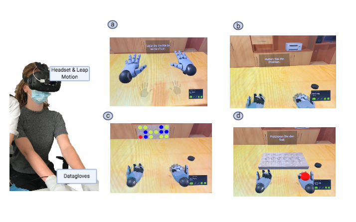

Task Design: every trail consists of the same four steps. The first two steps are calibration stages. The last two are part of the memory task **A)** Over the table position calibration **B)** Turning the palms for orientation calibration **C)** Fixating the correct red ball position **D)** Placing the red ball on the correct recalled position

# 2. Data Processing & Methods of Analysis

### (re-do ) Data Description

The variable ‘start’ corresponds to the moment the ball is placed in the hand of the participant. The number represents the row position in the original raw data. Likewise, ‘end’ corresponds to the explosion of the board and it also represents a row position in the original raw data.

The variable ‘accuracy’ takes value 1 when there is a mistake 0 otherwise.

The variable ‘diff’ refers to the time difference between ‘start’ and ‘end’, expressed in seconds and to finalize the categorical variable ‘stimulus’ signals whether the participant felt the vibration on the same hand the see the ball placed or not.

There are some trails being left out due to participants taking longer than 6 seconds to answer, when placed the ball not being recognized, or if there was a ezPlotdata glove failure.

```
      set             lvl             end             start
 Min.   :1.000   Min.   : 0.00   Min.   :  2255   Min.   :  1824
 1st Qu.:1.000   1st Qu.: 8.00   1st Qu.: 88625   1st Qu.: 88018
 Median :2.000   Median :17.00   Median :163684   Median :163204
 Mean   :2.036   Mean   :17.17   Mean   :164554   Mean   :164059
 3rd Qu.:3.000   3rd Qu.:26.00   3rd Qu.:239455   3rd Qu.:238937
 Max.   :3.000   Max.   :34.00   Max.   :391406   Max.   :390966

      diff              stimulus        ptcp         accuracy
 Min.   :3.120   base       :691   1      : 103   Min.   :0.00000
 1st Qu.:3.263   Incongruent:671   14     : 102   1st Qu.:0.00000
 Median :3.436   Congruent  :680   13     : 101   Median :0.00000
 Mean   :3.722                     2      : 100   Mean   :0.05681
 3rd Qu.:3.977                     15     : 100   3rd Qu.:0.00000
 Max.   :6.000                     19     :  99   Max.   :1.00000
                                   (Other):1437
```

# 3. Preliminary Analysis

In total there where 22 people included in the experiment, not counting 5 individuals who perform a pilot version of it. From the 22 persons included the age range goes from 18 to 50 $(M=24.14,SD=6.42)$ normally distributed. There were 17 female participants and 5 male participants.

#### Behavioral

The within participants ANOVA results for Response Time were significant $[F(2,42)= 3.52, SSn= 0.03, p = 0.03^* ,\eta^{2}=0.003]$. The response time range for base stimuli was between 3.12s to 6.00s $(M=3.75 s, SD=0.64)$, for incongruent visuo-haptic stimuli was from 3.12 to 5.97 $(M=3.72s, SD=0.63)$ and for the congruent visuo-haptic stimuli it was from 3.13 to 5.96 $(M=3.69s, SD=0.62)$ .

#### Questionaires

After the VR experience participants on average reported lower heart rate count for the post VR $(M=49.25,SD=20.04)$ case than the pre VR case $(M=57.28, SD=19.45)$. The difference is significant while running an ANOVA.

```r
a<- aov(meta[,8]  ~ meta[,7])
summary(a)
```

```
            Df Sum Sq Mean Sq F value Pr(>F)
meta[, 7]    1   2109  2108.6   6.865 0.0174 *
Residuals   18   5529   307.2
---
Signif. codes:  0 '***' 0.001 '**' 0.01 '*' 0.05 '.' 0.1 ' ' 1
2 observations deleted due to missingness
```

# 4. Main Results

### **Multi-level Model**

We fitted a multi-level model that explained response time (diff) (This were the results found significant in the previous preliminary analysis). On this model we have as fixed effects: trial level, set number and stimulus conditionS. As random effects we are considering the participant (ptcp) variable. The formulation would look something like this:
$$diff = 1+stimulus+lvl+set+(1|ptcp)$$
.

***From a Behavior stand point, the coherence of the viuso-haptic stimuli notably makes the reaction faster. Nonetheless, the fact that there is not a significant result for the incongruent visuo-haptic stimuli might cast some light on the multisensory integration of ambiguous sources. As observed in the preliminary results section, the significant difference is between no visuo-haptic stimuli and congruent visuo-haptic stimuli. The incongruent case sits between this two. As an intermediate case, where none is the slowest and congruent is the fastest**

```r
################### Randome Intercept Model for Response Time
rndintercepmodel <- lmer(diff~1+(1|ptcp),REML = F,tsvr)
summary(rndintercepmodel)
```

```
Linear mixed model fit by maximum likelihood . t-tests use
  Satterthwaite's method [lmerModLmerTest]
Formula: diff ~ 1 + (1 | ptcp)
   Data: tsvr

     AIC      BIC   logLik deviance df.resid
  3244.1   3261.0  -1619.1   3238.1     2039

Scaled residuals:
    Min      1Q  Median      3Q     Max
-2.1527 -0.5348 -0.2169  0.2759  4.8949

Random effects:
 Groups   Name        Variance Std.Dev.
 ptcp     (Intercept) 0.1533   0.3915
 Residual             0.2740   0.5234
Number of obs: 2042, groups:  ptcp, 22

Fixed effects:
            Estimate Std. Error       df t value Pr(>|t|)
(Intercept)  3.75090    0.08428 21.75078   44.51   <2e-16 ***
---
Signif. codes:  0 '***' 0.001 '**' 0.01 '*' 0.05 '.' 0.1 ' ' 1
```

```r
confint(rndintercepmodel)
```

```
                2.5 %    97.5 %
.sig01      0.2964281 0.5465948
.sigma      0.5076710 0.5399713
(Intercept) 3.5782908 3.9237791
```

```r
# Calculating ICC
ICC(outcom="diff", group="ptcp", data=tsvr)
```

```
[1] 0.3698515
```

```r
# adding 1 level predictors
rndintercepmodel1 <- lmer(diff~1+lvl+set+(1|ptcp),REML = F,tsvr)
summary(rndintercepmodel1)
```

```
Linear mixed model fit by maximum likelihood . t-tests use
  Satterthwaite's method [lmerModLmerTest]
Formula: diff ~ 1 + lvl + set + (1 | ptcp)
   Data: tsvr

     AIC      BIC   logLik deviance df.resid
  3041.9   3070.0  -1515.9   3031.9     2037

Scaled residuals:
    Min      1Q  Median      3Q     Max
-2.1087 -0.5914 -0.1656  0.3035  4.8509

Random effects:
 Groups   Name        Variance Std.Dev.
 ptcp     (Intercept) 0.1572   0.3964
 Residual             0.2473   0.4973
Number of obs: 2042, groups:  ptcp, 22

Fixed effects:
              Estimate Std. Error         df t value Pr(>|t|)
(Intercept)  4.203e+00  9.164e-02  2.908e+01  45.866   <2e-16 ***
lvl         -2.963e-03  1.087e-03  2.020e+03  -2.724   0.0065 **
set         -1.968e-01  1.354e-02  2.020e+03 -14.533   <2e-16 ***
---
Signif. codes:  0 '***' 0.001 '**' 0.01 '*' 0.05 '.' 0.1 ' ' 1

Correlation of Fixed Effects:
    (Intr) lvl
lvl -0.210
set -0.305  0.019
```

```r
confint(rndintercepmodel1)
```

```
                   2.5 %        97.5 %
.sig01       0.300488854  0.5530927284
.sigma       0.482345276  0.5130339799
(Intercept)  4.017605404  4.3893629350
lvl         -0.005094899 -0.0008303157
set         -0.223358992 -0.1702490091
```

```r
# adding 1 level predictors final
rndintercepmodel2 <- lmer(diff~1+stimulus+lvl+set+(1|ptcp),REML = F,tsvr)
summary(rndintercepmodel2)
```

```
Linear mixed model fit by maximum likelihood . t-tests use
  Satterthwaite's method [lmerModLmerTest]
Formula: diff ~ 1 + stimulus + lvl + set + (1 | ptcp)
   Data: tsvr

     AIC      BIC   logLik deviance df.resid
  3040.5   3079.8  -1513.2   3026.5     2035

Scaled residuals:
    Min      1Q  Median      3Q     Max
-2.1777 -0.5895 -0.1741  0.3072  4.8460

Random effects:
 Groups   Name        Variance Std.Dev.
 ptcp     (Intercept) 0.1573   0.3966
 Residual             0.2466   0.4966
Number of obs: 2042, groups:  ptcp, 22

Fixed effects:
                      Estimate Std. Error         df t value Pr(>|t|)
(Intercept)          4.235e+00  9.293e-02  3.071e+01  45.575  < 2e-16 ***
stimulusIncongruent -3.422e-02  2.696e-02  2.020e+03  -1.269  0.20448
stimulusCongruent   -6.253e-02  2.685e-02  2.020e+03  -2.329  0.01996 *
lvl                 -2.935e-03  1.086e-03  2.020e+03  -2.703  0.00693 **
set                 -1.971e-01  1.352e-02  2.020e+03 -14.571  < 2e-16 ***
---
Signif. codes:  0 '***' 0.001 '**' 0.01 '*' 0.05 '.' 0.1 ' ' 1

Correlation of Fixed Effects:
            (Intr) stmlsI stmlsC lvl
stmlsIncngr -0.142
stmlsCngrnt -0.144  0.495
lvl         -0.204 -0.014 -0.010
set         -0.302  0.005  0.008  0.019
```

```r
confint(rndintercepmodel2)
```

```
                          2.5 %        97.5 %
.sig01               0.30061661  0.5533019273
.sigma               0.48169488  0.5123421838
(Intercept)          4.04747235  4.4238232042
stimulusIncongruent -0.08708655  0.0186457142
stimulusCongruent   -0.11517801 -0.0098833929
lvl                 -0.00506494 -0.0008056486
set                 -0.22357683 -0.1705367206
```

```r
# compmaring models
anova(rndintercepmodel,rndintercepmodel1,rndintercepmodel2)
```

```
Data: tsvr
Models:
rndintercepmodel: diff ~ 1 + (1 | ptcp)
rndintercepmodel1: diff ~ 1 + lvl + set + (1 | ptcp)
rndintercepmodel2: diff ~ 1 + stimulus + lvl + set + (1 | ptcp)
                  npar    AIC    BIC  logLik deviance    Chisq Df
rndintercepmodel     3 3244.1 3261.0 -1619.1   3238.1
rndintercepmodel1    5 3041.9 3070.0 -1515.9   3031.9 206.2414  2
rndintercepmodel2    7 3040.5 3079.8 -1513.2   3026.5   5.4352  2
                  Pr(>Chisq)
rndintercepmodel
rndintercepmodel1    < 2e-16 ***
rndintercepmodel2    0.06603 .
---
Signif. codes:  0 '***' 0.001 '**' 0.01 '*' 0.05 '.' 0.1 ' ' 1
```

# 5. Heart data to include in main results section

### **Testing for IBI difference between conditions withing subjects (base, congruent, incongruent).**

try a different calculation using circular statistics.

a.- Inter beat intervals where detected using Hooman Sedghamiz (2018) algorithm. I consider the two seconds after the vibrations starts. The analysis was run without getting into detail of artifact removal.The removal of IBI where done using ‘rmoutliers’ MATLAB function.

At this point there were no significant difference between beat intervals.

```r
output_anova2 = ezANOVA(data = tsvr2,
                       dv = IBI,
                       wid = ptcp,
                       within = .(stimulus),
                       within_covariates = .(set),
                       detailed = T)
print(output_anova2)
```

```
$ANOVA
       Effect DFn DFd          SSn         SSd           F            p
1 (Intercept)   1  15 2.940031e+01 0.459848306 959.0220688 5.200574e-15
2    stimulus   2  30 2.908469e-05 0.002686637   0.1623853 8.508558e-01
  p<.05          ges
1     * 9.845114e-01
2       6.287711e-05

$`Mauchly's Test for Sphericity`
    Effect         W         p p<.05
2 stimulus 0.7226144 0.1028837

$`Sphericity Corrections`
    Effect      GGe     p[GG] p[GG]<.05       HFe     p[HF] p[HF]<.05
2 stimulus 0.782849 0.7990204           0.8579221 0.8190892
```

### Graphic

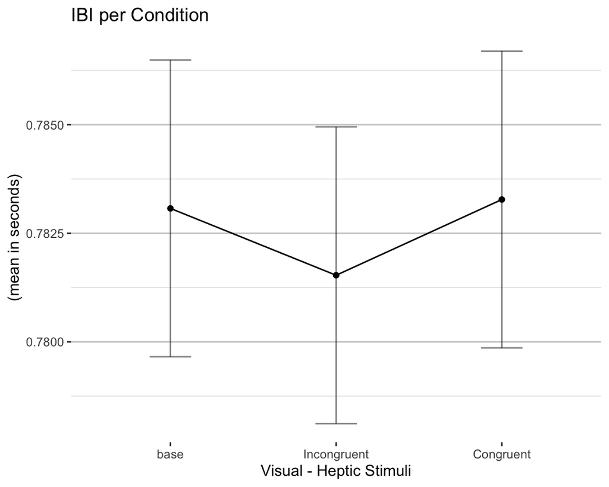

# 5. Interpretation